# Classification iii

2024-04-08

## Load Packages

The tidyverse is loaded in for you in the code chunk below. The visualization package, ggplot2, and the data manipulation package, dplyr, are part of the “larger” tidyverse.

```r
library(tidyverse)
```

The modelr package is loaded in for you in the code chunk below. You may use functions from modelr to calculate performance metrics for your models.

```r
library(modelr)
```

The caret package to manage all aspects of data splitting, training, and evaluating the models.

```r
library(caret)
```

## Import Data

```r
# Importing training data
train_data_path <- 'paint_project_train_data.csv'
df_train <- readr::read_csv(train_data_path, col_names = TRUE)
df_train %>% glimpse()
```

```
## Rows: 835
## Columns: 8
## $ R          <dbl> 172, 26, 172, 28, 170, 175, 90, 194, 171, 122, 0, 88, 144, …
## $ G          <dbl> 58, 88, 94, 87, 66, 89, 78, 106, 68, 151, 121, 140, 82, 163…
## $ B          <dbl> 62, 151, 58, 152, 58, 65, 136, 53, 107, 59, 88, 58, 132, 50…
## $ Lightness  <chr> "dark", "dark", "dark", "dark", "dark", "dark", "dark", "da…
## $ Saturation <chr> "bright", "bright", "bright", "bright", "bright", "bright",…
## $ Hue        <dbl> 4, 31, 8, 32, 5, 6, 34, 10, 1, 21, 24, 22, 36, 16, 26, 12, …
## $ response   <dbl> 12, 10, 16, 10, 11, 16, 10, 19, 14, 25, 14, 19, 14, 38, 15,…
## $ outcome    <dbl> 1, 1, 1, 0, 0, 0, 0, 0, 0, 0, 0, 0, 0, 0, 0, 0, 0, 0, 1, 1,…
```

**Levels of the binary outcome**

```r
df_train %>% count(outcome)
```

```
## # A tibble: 2 × 2
##   outcome     n
##     <dbl> <int>
## 1       0   644
## 2       1   191
```

Convert Categorical Variables to Factors to ensure that the categorical variables are treated as factors.

```r
df_train$Lightness <- as.factor(df_train$Lightness)
df_train$Saturation <- as.factor(df_train$Saturation)
```

Use the mean() function to determine the fraction (or proportion) of the observations that correspond to the event of interest. Is the data set a balanced data set?

```r
proportion_of_interest <- mean(df_train$outcome)
proportion_of_interest
```

```
## [1] 0.2287425
```

```r
df_caret <- df_train %>%
  mutate(outcome = ifelse(outcome == 1, 'event', 'non_event')) %>%
  mutate(outcome = factor(outcome, levels = c("event", "non_event"))) %>%
  select(R, G, B,Lightness, Saturation, Hue, response, outcome)

df_caret %>% glimpse()
```

```
## Rows: 835
## Columns: 8
## $ R          <dbl> 172, 26, 172, 28, 170, 175, 90, 194, 171, 122, 0, 88, 144, …
## $ G          <dbl> 58, 88, 94, 87, 66, 89, 78, 106, 68, 151, 121, 140, 82, 163…
## $ B          <dbl> 62, 151, 58, 152, 58, 65, 136, 53, 107, 59, 88, 58, 132, 50…
## $ Lightness  <fct> dark, dark, dark, dark, dark, dark, dark, dark, dark, dark,…
## $ Saturation <fct> bright, bright, bright, bright, bright, bright, bright, bri…
## $ Hue        <dbl> 4, 31, 8, 32, 5, 6, 34, 10, 1, 21, 24, 22, 36, 16, 26, 12, …
## $ response   <dbl> 12, 10, 16, 10, 11, 16, 10, 19, 14, 25, 14, 19, 14, 38, 15,…
## $ outcome    <fct> event, event, event, non_event, non_event, non_event, non_e…
```

## Part iii: Classification

## Part iiia : Classification-GLM

1. Intercept-only model: No input variables

```r
mod1 <- glm(outcome ~ 1, family = binomial, data = df_train)
```

2. Categorical variables only – linear additive

```r
mod2 <- glm(outcome ~ Lightness + Saturation, family = binomial, data = df_train)
```

3. Continuous variables only – linear additive

```r
mod3 <- glm(outcome ~ R + G + B + Hue + response, family = binomial, data = df_train)
```

4. All categorical and continuous variables – linear additive

```r
mod4 <- glm(outcome ~ Lightness + Saturation + R + G + B + Hue + response, family = binomial, data = df_train)
```

5. Interaction of the categorical inputs with all continuous inputs main effects

```r
mod5 <- glm(outcome ~ Lightness * (R + G + B + Hue + response) + Saturation * (R + G + B + Hue + response), family = binomial,data = df_train)
```

6. Add categorical inputs to all main effect and all pairwise interactions of continuous inputs

```r
mod6 <- glm(outcome ~ Lightness + Saturation + (R + G + B + Hue + response)^2, family = binomial, data = df_train)
```

7.Interaction of the categorical inputs with all main effect and all pairwise interactions of continuous inputs

```r
mod7 <-  glm(outcome ~ Lightness * (R + G + B + Hue + response)^2 + Saturation * (R + G + B + Hue + response)^2, family = binomial, data = df_train)
```

8.Polynomial transformations for the continuous variables R, G, and B, as their distributions.

```r
mod8 <-  glm(outcome ~ poly(R, 2) + poly(G, 2) + poly(B, 2) + Hue + Lightness + Saturation, family = binomial, data = df_train)
```

9.Interaction terms between the polynomial-transformed continuous variables and the categorical variables

```r
mod9 <-  glm(outcome ~ (poly(R, 2) + poly(G, 2) + poly(B, 2) + Hue) * (Lightness + Saturation), family = binomial, data = df_train)
```

```
## Warning: glm.fit: fitted probabilities numerically 0 or 1 occurred
```

10. Interaction terms between the polynomial-transformed continuous variables themselves

```r
mod10 <-  glm(outcome ~ poly(R, 2) * poly(G, 2) + poly(R, 2) * poly(B, 2) + poly(R, 2) * poly(Hue, 2) + poly(G, 2) * poly(B, 2) + poly(G, 2) * poly(Hue, 2) + poly(B, 2) * poly(Hue, 2), family = binomial, data = df_train)
```

```
## Warning: glm.fit: fitted probabilities numerically 0 or 1 occurred
```

During the fitting of the generalized linear models for classification, the warning “glm.fit: fitted probabilities numerically 0 or 1 occurred” is commonly encountered in logistic regression. This warning indicates potential issues with complete or quasi-complete separation in the data, which can affect the reliability and interpretation of the model’s coefficients.

**AIC and BIC metrics used to find the best performing model**

```r
model_aic <- tibble(
  Model = c("mod1", "mod2", "mod3", "mod4", "mod5", "mod6", "mod7", "mod8","mod9", "mod10"),
  AIC = c(
    broom::glance(mod1)$AIC,
    broom::glance(mod2)$AIC,
    broom::glance(mod3)$AIC,
    broom::glance(mod4)$AIC,
    broom::glance(mod5)$AIC,
    broom::glance(mod6)$AIC,
    broom::glance(mod7)$AIC,
    broom::glance(mod8)$AIC,
    broom::glance(mod9)$AIC,
    broom::glance(mod10)$AIC
  )
)

model_aic <- model_aic %>%
arrange(AIC)


model_aic
```

```
## # A tibble: 10 × 2
##    Model   AIC
##    <chr> <dbl>
##  1 mod10  566.
##  2 mod6   656.
##  3 mod9   660.
##  4 mod5   696.
##  5 mod8   716.
##  6 mod4   721.
##  7 mod2   740.
##  8 mod3   879.
##  9 mod1   900.
## 10 mod7  6688.
```

```r
model_bic <- tibble(
  Model = c("mod1", "mod2", "mod3", "mod4", "mod5", "mod6", "mod7", "mod8","mod9", "mod10"),
  BIC = c(
    broom::glance(mod1)$BIC,
    broom::glance(mod2)$BIC,
    broom::glance(mod3)$BIC,
    broom::glance(mod4)$BIC,
    broom::glance(mod5)$BIC,
    broom::glance(mod6)$BIC,
    broom::glance(mod7)$BIC,
    broom::glance(mod8)$BIC,
    broom::glance(mod9)$BIC,
    broom::glance(mod10)$BIC
  )
)

model_bic <- model_bic %>%
arrange(BIC)


model_bic
```

```
## # A tibble: 10 × 2
##    Model   BIC
##    <chr> <dbl>
##  1 mod10  722.
##  2 mod6   788.
##  3 mod2   801.
##  4 mod4   806.
##  5 mod8   810.
##  6 mod1   905.
##  7 mod3   907.
##  8 mod5  1065.
##  9 mod9  1152.
## 10 mod7  7671.
```

The analysis of model performance using AIC and BIC metrics reveals that model 10 is identified as the best according AIC and BIC.

**Visualize the coefficient summaries for your top 3 models**

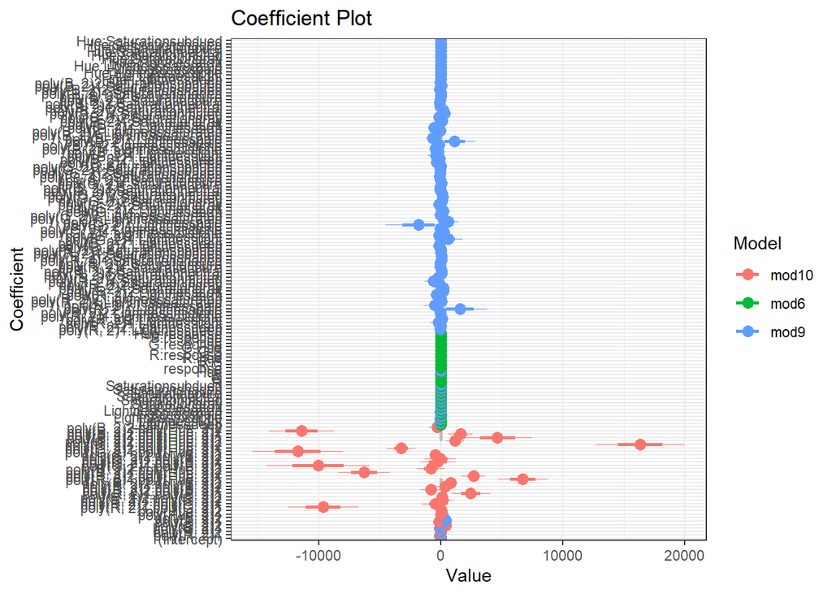

```r
library(coefplot)
multi_coef_plot <- coefplot::multiplot(mod10, mod6, mod9, dodgeHeight = 0.9) +
theme_bw()
multi_coef_plot
```

```r
summary_mod10 <- summary(mod10)$coefficients
summary_mod10
```

```
##                                Estimate  Std. Error    z value     Pr(>|z|)
## (Intercept)                   21.975639    3.546863  6.1957951 5.799151e-10
## poly(R, 2)1                 -112.461206   21.453132 -5.2421812 1.586894e-07
## poly(R, 2)2                   22.797919   21.129988  1.0789366 2.806160e-01
## poly(G, 2)1                  -76.129199   70.432737 -1.0808780 2.797514e-01
## poly(G, 2)2                  411.687353   59.445602  6.9254467 4.346019e-12
## poly(B, 2)1                 -142.532345   41.133214 -3.4651400 5.299554e-04
## poly(B, 2)2                   39.061246   23.627364  1.6532207 9.828596e-02
## poly(Hue, 2)1                  7.546462   15.030964  0.5020611 6.156246e-01
## poly(Hue, 2)2                 49.186499   13.694872  3.5915997 3.286544e-04
## poly(R, 2)1:poly(G, 2)1    -9629.477833 1437.143110 -6.7004307 2.078061e-11
## poly(R, 2)2:poly(G, 2)1     -442.943164  538.139208 -0.8231015 4.104503e-01
## poly(R, 2)1:poly(G, 2)2      135.121632  447.934733  0.3016547 7.629153e-01
## poly(R, 2)2:poly(G, 2)2       93.354464  174.213560  0.5358622 5.920538e-01
## poly(R, 2)1:poly(B, 2)1     2459.909125  787.213332  3.1248316 1.779069e-03
## poly(R, 2)2:poly(B, 2)1     -791.135600  447.712689 -1.7670609 7.721803e-02
## poly(R, 2)1:poly(B, 2)2      349.999729  376.131577  0.9305247 3.520995e-01
## poly(R, 2)2:poly(B, 2)2      802.132095  224.830443  3.5677201 3.601008e-04
## poly(R, 2)1:poly(Hue, 2)1   6715.202699 1034.518132  6.4911406 8.518890e-11
## poly(R, 2)2:poly(Hue, 2)1   2666.738358  483.639940  5.5138919 3.509842e-08
## poly(R, 2)1:poly(Hue, 2)2  -6297.628718 1063.924050 -5.9192465 3.234199e-09
## poly(R, 2)2:poly(Hue, 2)2   -804.060291  563.472025 -1.4269746 1.535872e-01
## poly(G, 2)1:poly(B, 2)1   -10058.897127 2123.129813 -4.7377683 2.160847e-06
## poly(G, 2)2:poly(B, 2)1     -227.391668  724.269095 -0.3139602 7.535513e-01
## poly(G, 2)1:poly(B, 2)2      -45.626553  625.531966 -0.0729404 9.418535e-01
## poly(G, 2)2:poly(B, 2)2     -440.287560  158.712251 -2.7741246 5.535047e-03
## poly(G, 2)1:poly(Hue, 2)1 -11709.538903 1862.983083 -6.2853705 3.270727e-10
## poly(G, 2)2:poly(Hue, 2)1  -3240.727655  576.783070 -5.6186248 1.924833e-08
## poly(G, 2)1:poly(Hue, 2)2  16311.142426 1828.694900  8.9195537 4.681709e-19
## poly(G, 2)2:poly(Hue, 2)2   1177.194215  373.460694  3.1521235 1.620877e-03
## poly(B, 2)1:poly(Hue, 2)1   4630.248991 1442.552913  3.2097602 1.328457e-03
## poly(B, 2)2:poly(Hue, 2)1   1615.417373  496.580592  3.2530820 1.141606e-03
## poly(B, 2)1:poly(Hue, 2)2 -11406.088825 1338.239742 -8.5232029 1.552006e-17
## poly(B, 2)2:poly(Hue, 2)2   -299.379701  354.364875 -0.8448346 3.982032e-01
```

```r
summary_mod6 <- summary(mod6)$coefficients
summary_mod6
```

```
##                         Estimate   Std. Error     z value     Pr(>|z|)
## (Intercept)         1.373203e+01 5.8671991928  2.34047365 1.925930e-02
## Lightnessdeep       8.697960e-01 0.6208394303  1.40099992 1.612141e-01
## Lightnesslight      2.232492e+00 1.2857470972  1.73633855 8.250399e-02
## Lightnessmidtone    2.322570e+00 1.0893165724  2.13213536 3.299572e-02
## Lightnesspale       2.880886e+00 1.3264667428  2.17184942 2.986702e-02
## Lightnesssaturated  1.355217e+00 0.8931184262  1.51739907 1.291660e-01
## Lightnesssoft       2.646554e+00 1.1998632159  2.20571307 2.740410e-02
## Saturationgray      6.720953e+00 0.7336411997  9.16108964 5.137590e-20
## Saturationmuted     1.156422e+00 0.6057768203  1.90899073 5.626329e-02
## Saturationneutral   4.327237e+00 0.6354866209  6.80932753 9.805601e-12
## Saturationpure      7.924001e-01 0.5972911858  1.32665634 1.846224e-01
## Saturationshaded    3.589172e+00 0.6168690916  5.81836822 5.942488e-09
## Saturationsubdued   2.728972e+00 0.5978596509  4.56456995 5.005193e-06
## R                   1.415418e-02 0.0298724384  0.47382087 6.356276e-01
## G                  -1.456548e-01 0.0652884336 -2.23094328 2.568489e-02
## B                  -2.376078e-01 0.0629467109 -3.77474498 1.601714e-04
## Hue                -1.897765e-01 0.1203731369 -1.57656860 1.148948e-01
## response            3.470543e-01 0.2361487491  1.46964261 1.416586e-01
## R:G                 7.383740e-05 0.0003155295  0.23401108 8.149764e-01
## R:B                 2.526962e-04 0.0002063073  1.22485356 2.206304e-01
## R:Hue              -2.861602e-03 0.0010235084 -2.79587537 5.175936e-03
## R:response         -7.183297e-04 0.0007607080 -0.94429098 3.450210e-01
## G:B                 9.885700e-04 0.0004801276  2.05897348 3.949678e-02
## G:Hue               4.623844e-05 0.0018368866  0.02517218 9.799176e-01
## G:response          1.535007e-03 0.0006131729  2.50338453 1.230118e-02
## B:Hue               6.072353e-03 0.0014036458  4.32612925 1.517524e-05
## B:response         -2.659451e-03 0.0009639724 -2.75884578 5.800590e-03
## Hue:response       -7.462542e-03 0.0032315882 -2.30924916 2.092976e-02
```

```r
summary_mod9 <- summary(mod9)$coefficients
summary_mod9
```

```
##                                     Estimate   Std. Error     z value
## (Intercept)                     9.937830e+00 7.983329e+00  1.24482271
## poly(R, 2)1                    -2.516336e+01 7.057046e+01 -0.35657075
## poly(R, 2)2                     1.803803e+01 3.389898e+01  0.53211132
## poly(G, 2)1                    -4.248193e+01 1.030389e+02 -0.41229016
## poly(G, 2)2                     1.902133e+01 3.318589e+01  0.57317515
## poly(B, 2)1                     4.179611e+02 1.774696e+02  2.35511395
## poly(B, 2)2                     1.816011e+02 6.212217e+01  2.92328901
## Hue                            -2.441132e-01 1.444341e-01 -1.69013552
## Lightnessdeep                  -2.536521e+01 1.281157e+01 -1.97986756
## Lightnesslight                 -2.798353e+01 1.530451e+01 -1.82844987
## Lightnessmidtone               -2.195696e+01 8.008667e+00 -2.74165020
## Lightnesspale                  -4.677448e+01 2.766225e+01 -1.69091395
## Lightnesssaturated             -1.409263e+01 7.594839e+00 -1.85555388
## Lightnesssoft                  -8.568027e+00 8.635783e+00 -0.99215404
## Saturationgray                  5.620417e+00 3.075006e+00  1.82777461
## Saturationmuted                -1.382402e+01 6.489084e+00 -2.13035028
## Saturationneutral               5.583111e+00 2.700847e+00  2.06717015
## Saturationpure                  2.936006e+00 3.042481e+00  0.96500384
## Saturationshaded                4.669334e+00 2.718646e+00  1.71752173
## Saturationsubdued               3.306998e+00 2.769442e+00  1.19410266
## poly(R, 2)1:Lightnessdeep      -6.700287e+01 9.311604e+01 -0.71956314
## poly(R, 2)2:Lightnessdeep       1.001959e+01 4.623960e+01  0.21668848
## poly(R, 2)1:Lightnesslight     -1.967964e+02 3.609461e+02 -0.54522363
## poly(R, 2)2:Lightnesslight      1.112029e+02 1.843514e+02  0.60321183
## poly(R, 2)1:Lightnessmidtone   -1.540999e+01 5.023942e+01 -0.30673111
## poly(R, 2)2:Lightnessmidtone   -2.455489e+01 5.435954e+01 -0.45171262
## poly(R, 2)1:Lightnesspale       1.548881e+03 1.129410e+03  1.37140731
## poly(R, 2)2:Lightnesspale      -4.952318e+02 4.695168e+02 -1.05476896
## poly(R, 2)1:Lightnesssaturated  3.421575e+01 3.490452e+01  0.98026701
## poly(R, 2)2:Lightnesssaturated  2.623609e+01 2.263825e+01  1.15892755
## poly(R, 2)1:Lightnesssoft      -3.675840e+02 1.332098e+02 -2.75943580
## poly(R, 2)2:Lightnesssoft       2.094463e+02 7.626107e+01  2.74643820
## poly(R, 2)1:Saturationgray      1.909746e+02 1.912737e+02  0.99843630
## poly(R, 2)2:Saturationgray     -9.677976e+01 9.510477e+01 -1.01761205
## poly(R, 2)1:Saturationmuted    -6.271161e+02 3.353427e+02 -1.87007551
## poly(R, 2)2:Saturationmuted    -1.888960e+02 8.216868e+01 -2.29888067
## poly(R, 2)1:Saturationneutral   3.503952e+01 7.905081e+01  0.44325310
## poly(R, 2)2:Saturationneutral   3.971815e+01 3.523132e+01  1.12735358
## poly(R, 2)1:Saturationpure     -2.889822e+01 6.806240e+01 -0.42458424
```

[output cut: 155 more lines]

```
## poly(B, 2)2:Saturationshaded   0.0040013594
## poly(B, 2)1:Saturationsubdued  0.4632857034
## poly(B, 2)2:Saturationsubdued  0.0512819971
## Hue:Lightnessdeep              0.3554205564
## Hue:Lightnesslight             0.0106145943
## Hue:Lightnessmidtone           0.0008024701
## Hue:Lightnesspale              0.0031311671
## Hue:Lightnesssaturated         0.0039559937
## Hue:Lightnesssoft              0.0472123835
## Hue:Saturationgray             0.1758896854
## Hue:Saturationmuted            0.7549834078
## Hue:Saturationneutral          0.5817429444
## Hue:Saturationpure             0.9561617578
## Hue:Saturationshaded           0.5920336790
## Hue:Saturationsubdued          0.6017134711
```

## Part iiib : Classification - Bayesian GLM

**Design Matrix**

Model 9 was chosen as the second model in the analysis because it offers a more complex interaction between the predictors, potentially capturing non-linear relationships and interactions that the best model may miss. This complexity could lead to a better fit for the data, especially if there are non-linear relationships or interactions among the predictors that are important for predicting the outcome variable.

```r
Xmat_9 <- model.matrix( mod9$formula, data = df_train )

Xmat_10 <- model.matrix( mod10$formula, data = df_train)
```

The log-posterior function you will program requires the design matrix, the observed output vector, and the prior specification.

```r
info_9 <- list(
  yobs = df_train$outcome,
  design_matrix = Xmat_9,
  mu_beta = 0,
  tau_beta = 4.5
)

info_10 <- list(
  yobs = df_train$outcome,
  design_matrix = Xmat_10,
  mu_beta = 0,
  tau_beta = 4.5
)
```

**Log-posterior function for logistic regression**

```r
logistic_logpost <- function(unknowns, my_info)
{
  # extract the design matrix and assign to X
  X <- my_info$design_matrix

  # calculate the linear predictor
  eta <- as.vector( X %*% as.matrix(unknowns))

  # calculate the event probability
  mu <- boot::inv.logit(eta)

  # evaluate the log-likelihood
  log_lik <- sum(dbinom(x = my_info$yobs,
                        size = 1,
                        prob = mu,
                        log = TRUE))

  # evaluate the log-prior
  log_prior <- sum(dnorm(x = unknowns,
                         mean = my_info$mu_beta,
                         sd = my_info$tau_beta,
                         log = TRUE))

  # sum together
  log_lik + log_prior
}
```

my_laplace() function

```r
my_laplace <- function(start_guess, logpost_func, ...)
{
  # code adapted from the `LearnBayes`` function `laplace()`
  fit <- optim(start_guess,
               logpost_func,
               gr = NULL,
               ...,
               method = "BFGS",
               hessian = TRUE,
               control = list(fnscale = -1, maxit = 5001))

  mode <- fit$par
  post_var_matrix <- -solve(fit$hessian)
  p <- length(mode)
  int <- p/2 * log(2 * pi) + 0.5 * log(det(post_var_matrix)) + logpost_func(mode, ...)
  # package all of the results into a list
  list(mode = mode,
       var_matrix = post_var_matrix,
       log_evidence = int,
       converge = ifelse(fit$convergence == 0,
                         "YES",
                         "NO"),
       iter_counts = as.numeric(fit$counts[1]))
}
```

```r
laplace_9 <- my_laplace(rep(0, ncol(Xmat_9)), logistic_logpost, info_9)

laplace_10 <- my_laplace(rep(0, ncol(Xmat_10)), logistic_logpost, info_10)
```

**Best Model using the Evidence based approach**

```r
mod_log_evidences <- purrr::map_dbl(
  list(laplace_10, laplace_9),
  ~ .x$log_evidence
)

all_model_weights <- exp(mod_log_evidences) / sum(exp(mod_log_evidences))
```

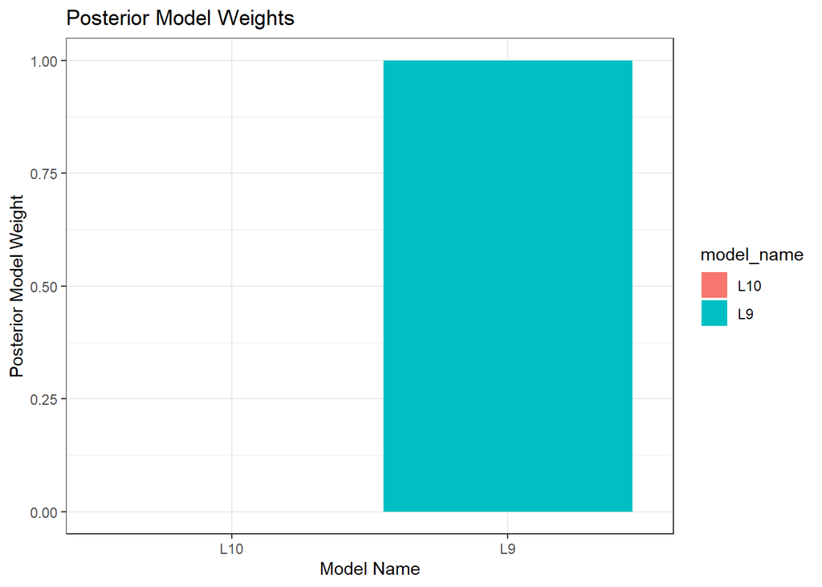

```r
tibble::tibble(
  model_name = c("L10", "L9"),
  post_model_weight = all_model_weights
) %>%
  ggplot(aes(x = model_name, y = post_model_weight, fill = model_name)) +
  geom_bar(stat = 'identity') +
  coord_cartesian(ylim = c(0,1)) +
  labs(title = "Posterior Model Weights", x = "Model Name", y = "Posterior Model Weight") +
  theme_bw()
```

The model L9 has a weight of 1.00, and L10 has a weight close to 0. This indicates that model L9 is considered the best model in comparison to L10, based on the posterior model weights displayed.

**Visualize the regression coefficient posterior summary statistics for your best model**

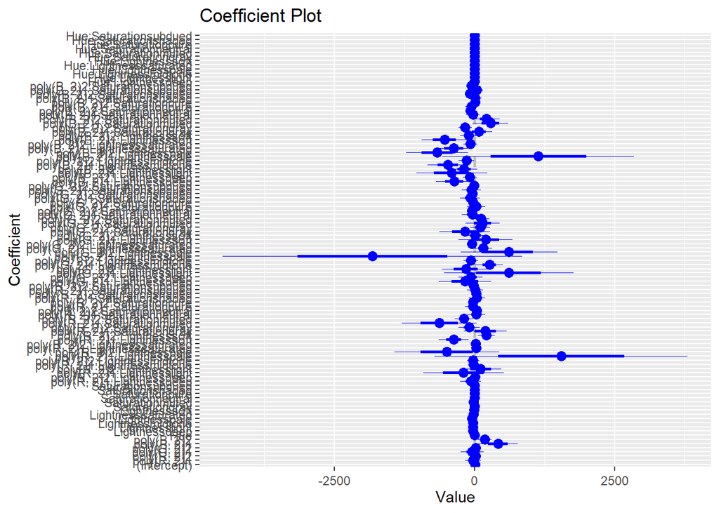

```r
coefplot(mod9)
```

```r
coef(mod9)
```

```
##                    (Intercept)                    poly(R, 2)1
##                   9.937830e+00                  -2.516336e+01
##                    poly(R, 2)2                    poly(G, 2)1
##                   1.803803e+01                  -4.248193e+01
##                    poly(G, 2)2                    poly(B, 2)1
##                   1.902133e+01                   4.179611e+02
##                    poly(B, 2)2                            Hue
##                   1.816011e+02                  -2.441132e-01
##                  Lightnessdeep                 Lightnesslight
##                  -2.536521e+01                  -2.798353e+01
##               Lightnessmidtone                  Lightnesspale
##                  -2.195696e+01                  -4.677448e+01
##             Lightnesssaturated                  Lightnesssoft
##                  -1.409263e+01                  -8.568027e+00
##                 Saturationgray                Saturationmuted
##                   5.620417e+00                  -1.382402e+01
##              Saturationneutral                 Saturationpure
##                   5.583111e+00                   2.936006e+00
##               Saturationshaded              Saturationsubdued
##                   4.669334e+00                   3.306998e+00
##      poly(R, 2)1:Lightnessdeep      poly(R, 2)2:Lightnessdeep
##                  -6.700287e+01                   1.001959e+01
##     poly(R, 2)1:Lightnesslight     poly(R, 2)2:Lightnesslight
##                  -1.967964e+02                   1.112029e+02
##   poly(R, 2)1:Lightnessmidtone   poly(R, 2)2:Lightnessmidtone
##                  -1.540999e+01                  -2.455489e+01
##      poly(R, 2)1:Lightnesspale      poly(R, 2)2:Lightnesspale
##                   1.548881e+03                  -4.952318e+02
## poly(R, 2)1:Lightnesssaturated poly(R, 2)2:Lightnesssaturated
##                   3.421575e+01                   2.623609e+01
##      poly(R, 2)1:Lightnesssoft      poly(R, 2)2:Lightnesssoft
##                  -3.675840e+02                   2.094463e+02
##     poly(R, 2)1:Saturationgray     poly(R, 2)2:Saturationgray
##                   1.909746e+02                  -9.677976e+01
##    poly(R, 2)1:Saturationmuted    poly(R, 2)2:Saturationmuted
##                  -6.271161e+02                  -1.888960e+02
##  poly(R, 2)1:Saturationneutral  poly(R, 2)2:Saturationneutral
##                   3.503952e+01                   3.971815e+01
##     poly(R, 2)1:Saturationpure     poly(R, 2)2:Saturationpure
##                  -2.889822e+01                  -2.715700e+01
```

[output cut: 49 more lines]

```
##                   1.381827e+01                  -8.099344e+01
##  poly(B, 2)1:Saturationsubdued  poly(B, 2)2:Saturationsubdued
##                   4.060314e+01                  -5.832443e+01
##              Hue:Lightnessdeep             Hue:Lightnesslight
##                   8.768212e-02                   2.684206e-01
##           Hue:Lightnessmidtone              Hue:Lightnesspale
##                   3.204172e-01                   2.748069e-01
##         Hue:Lightnesssaturated              Hue:Lightnesssoft
##                   2.464160e-01                   2.101791e-01
##             Hue:Saturationgray            Hue:Saturationmuted
##                   2.245353e-01                  -9.493085e-02
##          Hue:Saturationneutral             Hue:Saturationpure
##                   7.084332e-02                  -7.940915e-03
##           Hue:Saturationshaded          Hue:Saturationsubdued
##                   6.849140e-02                   7.004979e-02
```

## Part iiic : Classification - GLM Predictions

```r
viz_grid <- expand.grid(R = unique(df_train$R),
                        G = unique(df_train$G),
                        B = unique(df_train$B),
                        Lightness = unique(df_train$Lightness),
                        KEEP.OUT.ATTRS = FALSE,
                        stringsAsFactors = FALSE) %>%
  as.data.frame() %>% tibble::as_tibble()

viz_grid %>% glimpse()
```

```
## Rows: 43,153,047
## Columns: 4
## $ R         <dbl> 172, 26, 28, 170, 175, 90, 194, 171, 122, 0, 88, 144, 214, 1…
## $ G         <dbl> 58, 58, 58, 58, 58, 58, 58, 58, 58, 58, 58, 58, 58, 58, 58, …
## $ B         <dbl> 62, 62, 62, 62, 62, 62, 62, 62, 62, 62, 62, 62, 62, 62, 62, …
## $ Lightness <fct> dark, dark, dark, dark, dark, dark, dark, dark, dark, dark, …
```

generate_lm_post_samples() function

```r
generate_glm_post_samples <- function(mvn_result, num_samples)
{
  # specify the number of unknown beta parameters
  length_beta <- length(mvn_result$mode)

  # generate the random samples
  beta_samples <- MASS::mvrnorm(n = num_samples,
                                mu = mvn_result$mode,
                                Sigma = mvn_result$var_matrix)

  # change the data type and name
  beta_samples %>%
    as.data.frame() %>% tibble::as_tibble() %>%
    purrr::set_names(sprintf("beta_%02d", (1:length_beta) - 1))
}
```

post_logistic_pred_samples() Function

```r
post_logistic_pred_samples <- function(Xnew, Bmat)
{
  # calculate the linear predictor at all prediction points and posterior samples
  eta_mat <- Xnew %*% t(Bmat)

  # calculate the event probability
  mu_mat <- boot::inv.logit(eta_mat)

  # book keeping
  list(eta_mat = eta_mat, mu_mat = mu_mat)
}
```

summarize_logistic_pred_from_laplace() Function

```r
summarize_logistic_pred_from_laplace <- function(mvn_result, Xtest, num_samples)
{
  # generate posterior samples of the beta parameters
  betas <- generate_glm_post_samples(mvn_result, num_samples)

  # data type conversion
  betas <- as.matrix(betas)

  # make posterior predictions on the test set
  pred_test <- post_logistic_pred_samples(Xtest, betas)

  # calculate summary statistics on the posterior predicted probability
  # summarize over the posterior samples

  # posterior mean, should you summarize along rows (rowMeans) or
  # summarize down columns (colMeans) ???
  mu_avg <- rowMeans(pred_test$mu_mat)

  # posterior quantiles
  mu_q05 <- apply(pred_test$mu_mat, 1, stats::quantile, probs = 0.05)
  mu_q95 <- apply(pred_test$mu_mat, 1, stats::quantile, probs = 0.95)

  # book keeping
  tibble::tibble(
    mu_avg = mu_avg,
    mu_q05 = mu_q05,
    mu_q95 = mu_q95
  ) %>%
    tibble::rowid_to_column("pred_id")
}
```

```r
Xviz_9 <- model.matrix( mod9$formula, data = df_train )
Xviz_10 <- model.matrix( mod10$formula, data = df_train)
```

```r
set.seed(8123)

post_pred_summary_9 <- summarize_logistic_pred_from_laplace(laplace_9, Xviz_9, 2500)

post_pred_summary_10 <- summarize_logistic_pred_from_laplace(laplace_10, Xviz_10, 2500)
```

```r
post_pred_summary_9 %>% dim()
```

```
## [1] 835   4
```

```r
post_pred_summary_9
```

```
## # A tibble: 835 × 4
##    pred_id mu_avg  mu_q05 mu_q95
##      <int>  <dbl>   <dbl>  <dbl>
##  1       1 0.305  0.111   0.558
##  2       2 0.0598 0.00949 0.175
##  3       3 0.0966 0.0340  0.194
##  4       4 0.0550 0.00801 0.166
##  5       5 0.230  0.0820  0.437
##  6       6 0.139  0.0494  0.278
##  7       7 0.0305 0.00304 0.0987
##  8       8 0.0614 0.0209  0.127
##  9       9 0.397  0.141   0.697
## 10      10 0.0152 0.00378 0.0389
## # ℹ 825 more rows
```

```r
post_pred_summary_10 %>% dim()
```

```
## [1] 835   4
```

```r
post_pred_summary_10
```

```
## # A tibble: 835 × 4
##    pred_id mu_avg mu_q05 mu_q95
##      <int>  <dbl>  <dbl>  <dbl>
##  1       1  0.373 0.252   0.509
##  2       2  0.381 0.257   0.512
##  3       3  0.202 0.143   0.273
##  4       4  0.376 0.254   0.506
##  5       5  0.317 0.216   0.432
##  6       6  0.226 0.165   0.296
##  7       7  0.428 0.317   0.545
##  8       8  0.139 0.0908  0.201
##  9       9  0.421 0.290   0.559
## 10      10  0.140 0.0866  0.207
## # ℹ 825 more rows
```

```r
viz_bayes_logpost_preds <- function(post_pred_summary, input_df)
{
  post_pred_summary %>%
    left_join(input_df %>% tibble::rowid_to_column('pred_id'),
              by = 'pred_id') %>%
    ggplot(mapping = aes(x = R)) +
    geom_ribbon(mapping = aes(ymin = mu_q05,
                              ymax = mu_q95,
                              group = interaction(Lightness, G),
                              fill = as.factor(Lightness)),
                alpha = 0.25) +
    geom_line(mapping = aes(y = mu_avg,
                            group = interaction(Lightness, G),
                            color = as.factor(Lightness)),
              size = 1.15) +
    facet_wrap(~ G, labeller = 'label_both') +
    labs(y = "Event Probability", x = "Red Color Intensity (R)") +
    theme_bw()
}
```

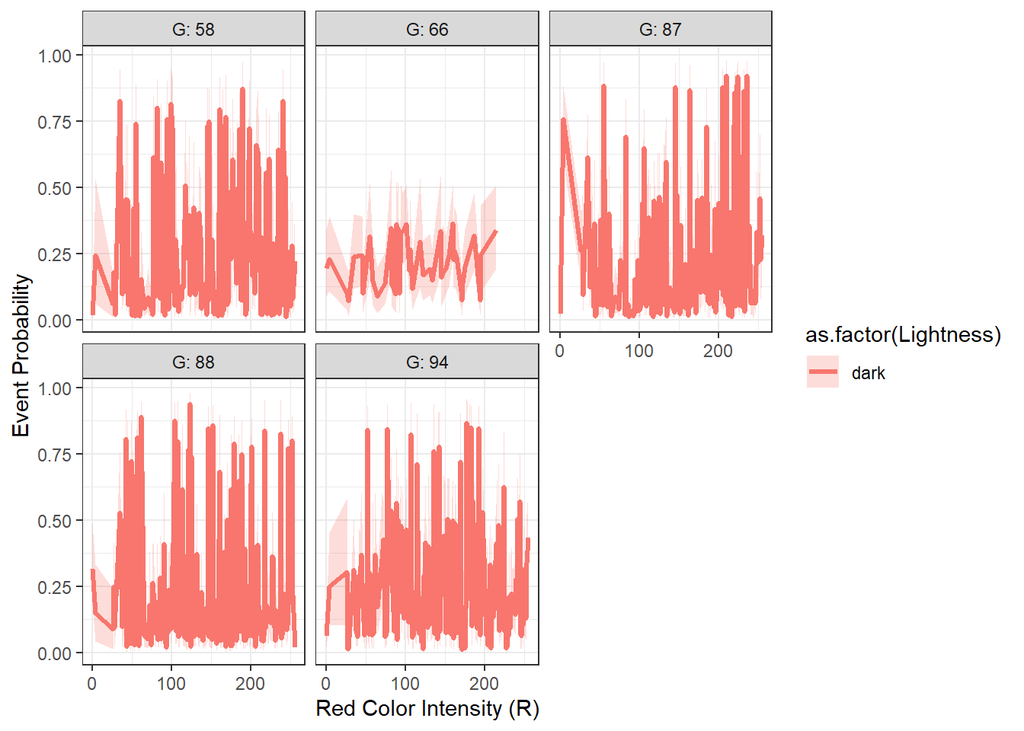

```r
viz_bayes_logpost_preds(post_pred_summary_9, viz_grid)
```

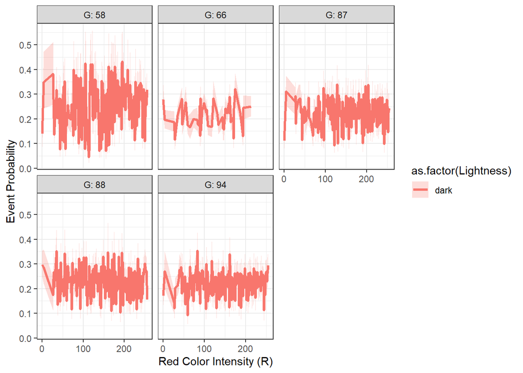

```r
viz_bayes_logpost_preds(post_pred_summary_10, viz_grid)
```

Upon reviewing the graphical outputs of the two generalized linear models, it appears that there may be some variation in the predictive trends between them. The trends represent the relationship between the red color intensity and the event probability when the lightness is characterized as “dark” across different levels of green intensity. In both sets of graphs, as we look across the panels corresponding to different levels of green intensity, we should expect to see similar patterns if the models are consistent. Specifically, if increases or decreases in red intensity result in similar changes in event probability across both models, and if the variability captured by the confidence intervals is alike, we could conclude the trends are consistent. Visually, the trends should display corresponding shapes and directions for each level of green intensity to assert consistency.

## Part iiid : Classification - Train/tune with resampling

```r
df_caret <- df_train %>%
  mutate(outcome = ifelse(outcome == 1, 'event', 'non_event')) %>%
  mutate(outcome = factor(outcome, levels = c("event", "non_event"))) %>%
  select(R, G, B,Lightness, Saturation, Hue, response, outcome)

df_caret %>% glimpse()
```

```
## Rows: 835
## Columns: 8
## $ R          <dbl> 172, 26, 172, 28, 170, 175, 90, 194, 171, 122, 0, 88, 144, …
## $ G          <dbl> 58, 88, 94, 87, 66, 89, 78, 106, 68, 151, 121, 140, 82, 163…
## $ B          <dbl> 62, 151, 58, 152, 58, 65, 136, 53, 107, 59, 88, 58, 132, 50…
## $ Lightness  <fct> dark, dark, dark, dark, dark, dark, dark, dark, dark, dark,…
## $ Saturation <fct> bright, bright, bright, bright, bright, bright, bright, bri…
## $ Hue        <dbl> 4, 31, 8, 32, 5, 6, 34, 10, 1, 21, 24, 22, 36, 16, 26, 12, …
## $ response   <dbl> 12, 10, 16, 10, 11, 16, 10, 19, 14, 25, 14, 19, 14, 38, 15,…
## $ outcome    <fct> event, event, event, non_event, non_event, non_event, non_e…
```

```r
my_ctrl <- trainControl(method = 'repeatedcv', number = 10, repeats = 3)
my_metric <- "Accuracy"
```

**Generalized linear models**

1. All categorical and continuous variables

```r
set.seed(1234)
glm_default_01 <- train(outcome ~ Lightness + Saturation + R + G + B + Hue + response,
                       data = df_caret,
                       method = 'glm',
                       metric = my_metric,
                       preProcess = c("center", "scale"),
                       trControl = my_ctrl,
                       trace = FALSE)

glm_default_01
```

```
## Generalized Linear Model
##
## 835 samples
##   7 predictor
##   2 classes: 'event', 'non_event'
##
## Pre-processing: centered (17), scaled (17)
## Resampling: Cross-Validated (10 fold, repeated 3 times)
## Summary of sample sizes: 751, 751, 751, 752, 752, 752, ...
## Resampling results:
##
##   Accuracy   Kappa
##   0.8180109  0.3844327
```

2.Add categorical inputs to all main effect and all pairwise interactions of continuous inputs

```r
set.seed(1234)
glm_default_02 <- train(outcome ~ Lightness + Saturation + (R + G + B + Hue + response)^2,
                       data = df_caret,
                       method = 'glm',
                       metric = my_metric,
                       preProcess = c("center", "scale"),
                       trControl = my_ctrl,
                       trace = FALSE)

glm_default_02
```

```
## Generalized Linear Model
##
## 835 samples
##   7 predictor
##   2 classes: 'event', 'non_event'
##
## Pre-processing: centered (27), scaled (27)
## Resampling: Cross-Validated (10 fold, repeated 3 times)
## Summary of sample sizes: 751, 751, 751, 752, 752, 752, ...
## Resampling results:
##
##   Accuracy   Kappa
##   0.8188335  0.4291429
```

3. Continuous variables only

```r
set.seed(1234)
glm_default_03 <- train(outcome ~ R + G + B + Hue + response,
                       data = df_caret,
                       method = 'glm',
                       metric = my_metric,
                       preProcess = c("center", "scale"),
                       trControl = my_ctrl,
                       trace = FALSE)

glm_default_03
```

```
## Generalized Linear Model
##
## 835 samples
##   5 predictor
##   2 classes: 'event', 'non_event'
##
## Pre-processing: centered (5), scaled (5)
## Resampling: Cross-Validated (10 fold, repeated 3 times)
## Summary of sample sizes: 751, 751, 751, 752, 752, 752, ...
## Resampling results:
##
##   Accuracy   Kappa
##   0.7665043  0.009561404
```

4. Polynomial transformations for the continuous variables R, G, and B, as their distributions.

```r
set.seed(1234)
glm_default_04 <- train(outcome ~ poly(R, 2) + poly(G, 2) + poly(B, 2) + Hue + Lightness + Saturation,
                       data = df_caret,
                       method = 'glm',
                       metric = my_metric,
                       preProcess = c("center", "scale"),
                       trControl = my_ctrl,
                       trace = FALSE)

glm_default_04
```

```
## Generalized Linear Model
##
## 835 samples
##   6 predictor
##   2 classes: 'event', 'non_event'
##
## Pre-processing: centered (19), scaled (19)
## Resampling: Cross-Validated (10 fold, repeated 3 times)
## Summary of sample sizes: 751, 751, 751, 752, 752, 752, ...
## Resampling results:
##
##   Accuracy   Kappa
##   0.8239918  0.4022171
```

**Best performing model: my_metric - Accuracy**

```r
accuracy_model1 <- mean(glm_default_01$results$Accuracy)
accuracy_model2 <- mean(glm_default_02$results$Accuracy)
accuracy_model3 <- mean(glm_default_03$results$Accuracy)
accuracy_model4 <- mean(glm_default_04$results$Accuracy)


model_accuracies_glm <- tibble(
  Model = c("glm_default_01", "glm_default_02", "glm_default_03", "glm_default_04"),
  Accuracy = c(accuracy_model1, accuracy_model2, accuracy_model3, accuracy_model4)
)


model_accuracies_glm <- model_accuracies_glm %>%
  arrange(desc(Accuracy))

print(model_accuracies_glm)
```

```
## # A tibble: 4 × 2
##   Model          Accuracy
##   <chr>             <dbl>
## 1 glm_default_04    0.824
## 2 glm_default_02    0.819
## 3 glm_default_01    0.818
## 4 glm_default_03    0.767
```

The model labeled `glm_default_04` has an accuracy of 0.8239918, which means it correctly predicts the outcome of the classification task about 82.39% of the time. This accuracy rate is the highest among all the models created, indicating that `glm_default_04` is the most effective in predicting the outcome compared to the other models.

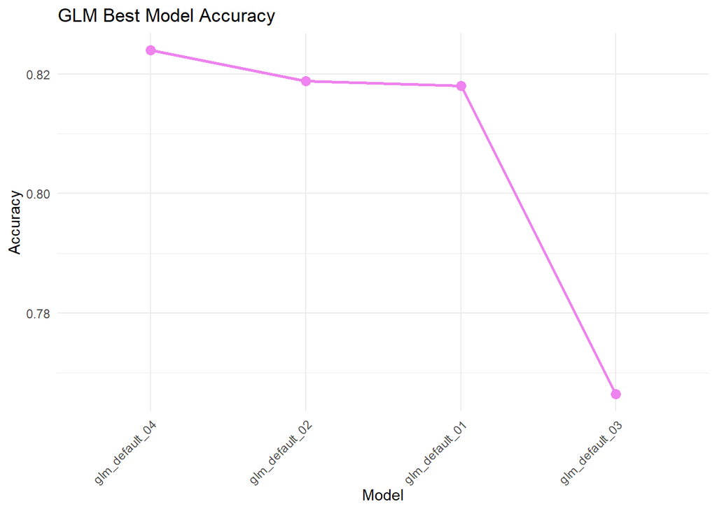

```r
ggplot(model_accuracies_glm, aes(x = reorder(Model, -Accuracy), y = Accuracy, group = 1)) +
  geom_line(color="violet", size = 1) +
  geom_point(color="violet",size = 3) +
  labs(x = "Model", y = "Accuracy", title = "GLM Best Model Accuracy") +
  theme_minimal() +
  theme(axis.text.x = element_text(angle = 45, hjust = 1),
        legend.position = "bottom")
```

**Regularized regression with Elastic net**

1. Add categorical inputs to all main effect and all pairwise interactions of continuous inputs

```r
set.seed(1234)

enet_default_01 <- train(outcome ~ Lightness + Saturation + (R + G + B + Hue + response)^2,                      data = df_caret,
                       method = 'glmnet',
                       metric = my_metric,
                       preProcess = c("center", "scale"),
                       trControl = my_ctrl,
                       trace = FALSE)

enet_default_01
```

```
## glmnet
##
## 835 samples
##   7 predictor
##   2 classes: 'event', 'non_event'
##
## Pre-processing: centered (27), scaled (27)
## Resampling: Cross-Validated (10 fold, repeated 3 times)
## Summary of sample sizes: 751, 751, 751, 752, 752, 752, ...
## Resampling results across tuning parameters:
##
##   alpha  lambda        Accuracy   Kappa
##   0.10   0.0003523518  0.8164331  0.3863761
##   0.10   0.0035235183  0.8219935  0.3779385
##   0.10   0.0352351830  0.8224094  0.3695368
##   0.55   0.0003523518  0.8176332  0.3957796
##   0.55   0.0035235183  0.8231935  0.3809917
##   0.55   0.0352351830  0.8228110  0.3705918
##   1.00   0.0003523518  0.8188332  0.4051448
##   1.00   0.0035235183  0.8228015  0.3764214
##   1.00   0.0352351830  0.8228110  0.3705918
##
## Accuracy was used to select the optimal model using the largest value.
## The final values used for the model were alpha = 0.55 and lambda = 0.003523518.
```

2. Interaction of the categorical inputs with all continuous inputs main effects

```r
set.seed(1234)

enet_default_02 <- train(outcome ~ Lightness * (R + G + B + Hue + response) + Saturation * (R + G + B + Hue + response),
                       data = df_caret,
                       method = 'glmnet',
                       metric = my_metric,
                       preProcess = c("center", "scale"),
                       trControl = my_ctrl,
                       trace = FALSE)

enet_default_02
```

```
## glmnet
##
## 835 samples
##   7 predictor
##   2 classes: 'event', 'non_event'
##
## Pre-processing: centered (77), scaled (77)
## Resampling: Cross-Validated (10 fold, repeated 3 times)
## Summary of sample sizes: 751, 751, 751, 752, 752, 752, ...
## Resampling results across tuning parameters:
##
##   alpha  lambda        Accuracy   Kappa
##   0.10   0.0003534478  0.8040599  0.3612428
##   0.10   0.0035344779  0.8096584  0.3532937
##   0.10   0.0353447789  0.8176379  0.3512227
##   0.55   0.0003534478  0.8048536  0.3628969
##   0.55   0.0035344779  0.8100600  0.3447148
##   0.55   0.0353447789  0.8200141  0.3574797
##   1.00   0.0003534478  0.8036584  0.3601816
##   1.00   0.0035344779  0.8104521  0.3340463
##   1.00   0.0353447789  0.8188235  0.3510898
##
## Accuracy was used to select the optimal model using the largest value.
## The final values used for the model were alpha = 0.55 and lambda = 0.03534478.
```

3.Polynomial transformations for the continuous variables R, G, and B, as their distributions.

```r
set.seed(1234)

enet_default_03 <- train(outcome ~ poly(R, 2) + poly(G, 2) + poly(B, 2) + Hue + Lightness + Saturation,
                       data = df_caret,
                       method = 'glmnet',
                       metric = my_metric,
                       preProcess = c("center", "scale"),
                       trControl = my_ctrl,
                       trace = FALSE)

enet_default_03
```

```
## glmnet
##
## 835 samples
##   6 predictor
##   2 classes: 'event', 'non_event'
##
## Pre-processing: centered (19), scaled (19)
## Resampling: Cross-Validated (10 fold, repeated 3 times)
## Summary of sample sizes: 751, 751, 751, 752, 752, 752, ...
## Resampling results across tuning parameters:
##
##   alpha  lambda        Accuracy   Kappa
##   0.10   0.0003523518  0.8231982  0.3988373
##   0.10   0.0035235183  0.8227966  0.3934661
##   0.10   0.0352351830  0.8207982  0.3723031
##   0.55   0.0003523518  0.8228013  0.3972058
##   0.55   0.0035235183  0.8219934  0.3887073
##   0.55   0.0352351830  0.8224094  0.3695368
##   1.00   0.0003523518  0.8219981  0.3943028
##   1.00   0.0035235183  0.8215965  0.3867844
##   1.00   0.0352351830  0.8228110  0.3705918
##
## Accuracy was used to select the optimal model using the largest value.
## The final values used for the model were alpha = 0.1 and lambda = 0.0003523518.
```

A custom tuning grid to further tune the elastic net lambda and alpha tuning parameters.

```r
my_lambda_grid_01 <- exp(seq(log(min(enet_default_01$results$lambda)),
                          log(max(enet_default_01$results$lambda)),
                          length.out = 25))


enet_grid_01 <- expand.grid(alpha = seq(0.1, 1.0, by = 0.1),
                         lambda = my_lambda_grid_01)


enet_grid_01 %>% dim()
```

```
## [1] 250   2
```

```r
my_lambda_grid_02 <- exp(seq(log(min(enet_default_02$results$lambda)),
                          log(max(enet_default_02$results$lambda)),
                          length.out = 25))


enet_grid_02 <- expand.grid(alpha = seq(0.1, 1.0, by = 0.1),
                         lambda = my_lambda_grid_02)


enet_grid_02 %>% dim()
```

```
## [1] 250   2
```

```r
my_lambda_grid_03 <- exp(seq(log(min(enet_default_03$results$lambda)),
                          log(max(enet_default_03$results$lambda)),
                          length.out = 25))


enet_grid_03 <- expand.grid(alpha = seq(0.1, 1.0, by = 0.1),
                         lambda = my_lambda_grid_03)


enet_grid_03 %>% dim()
```

```
## [1] 250   2
```

Train, assess, and tune the elastic net model with the custom tuning grid

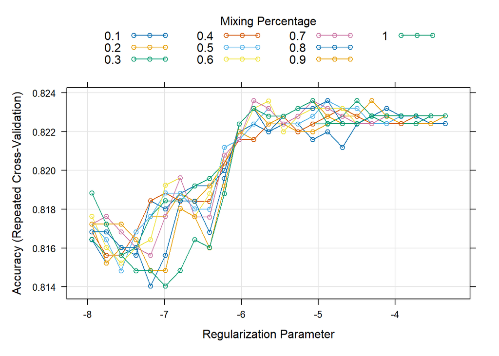

```r
set.seed(1234)
enet_tune_01 <- train(outcome ~ Lightness + Saturation + (R + G + B + Hue + response)^2,
                   data = df_caret,
                   method = 'glmnet',
                   metric = my_metric,
                   tuneGrid = enet_grid_01,
                   preProcess = c("center", "scale"),
                   trControl = my_ctrl)

plot(enet_tune_01, xTrans = log)
```

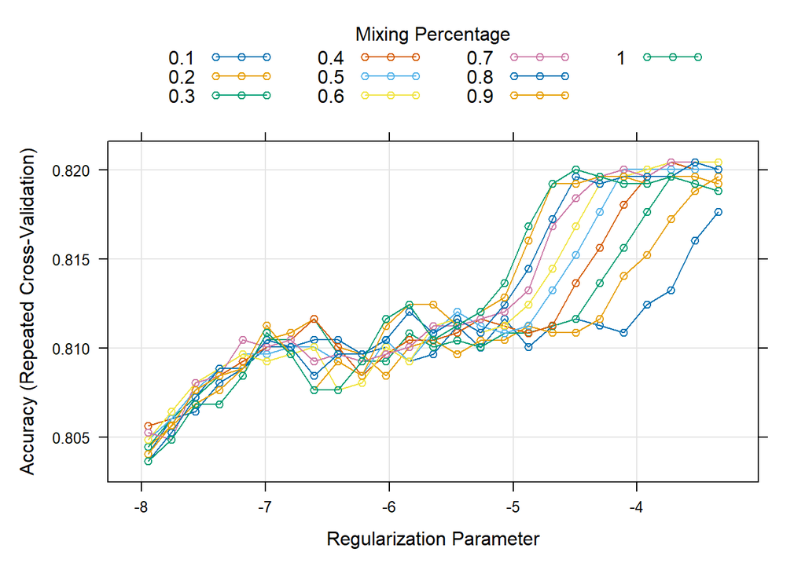

```r
set.seed(1234)
enet_tune_02 <- train(outcome ~ Lightness * (R + G + B + Hue + response) + Saturation * (R + G + B + Hue + response),
                   data = df_caret,
                   method = 'glmnet',
                   metric = my_metric,
                   tuneGrid = enet_grid_02,
                   preProcess = c("center", "scale"),
                   trControl = my_ctrl)

plot(enet_tune_02, xTrans = log)
```

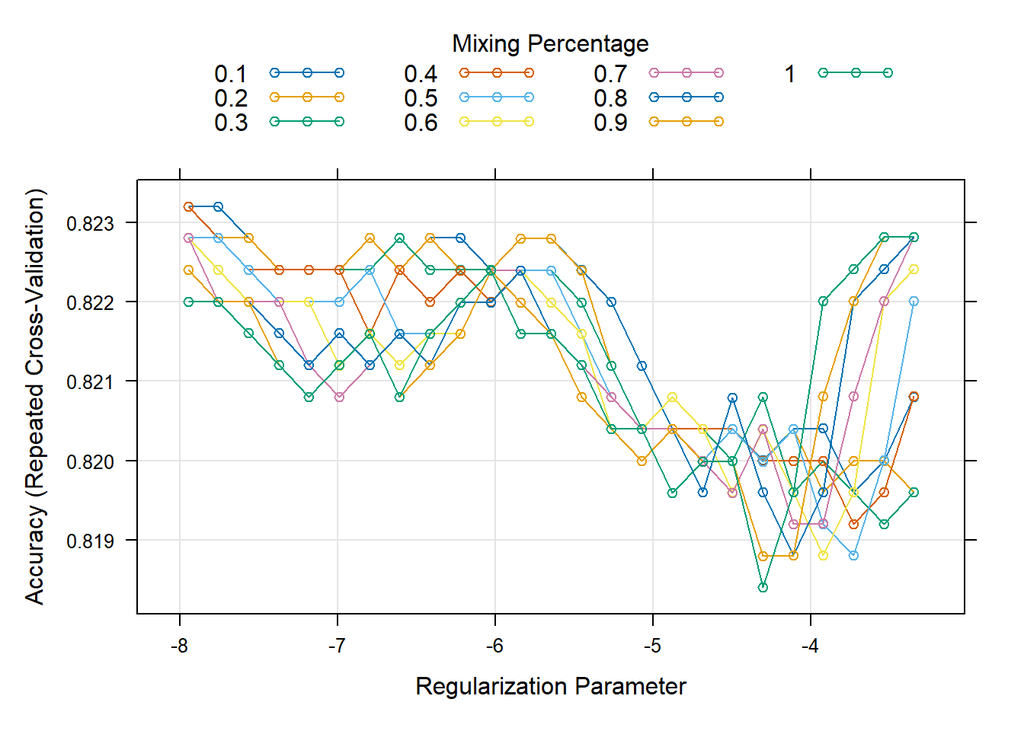

```r
set.seed(1234)
enet_tune_03 <- train(outcome ~ poly(R, 2) + poly(G, 2) + poly(B, 2) + Hue + Lightness + Saturation,
                   data = df_caret,
                   method = 'glmnet',
                   metric = my_metric,
                   tuneGrid = enet_grid_03,
                   preProcess = c("center", "scale"),
                   trControl = my_ctrl)

plot(enet_tune_03, xTrans = log)
```

```r
accuracy_model1e <- mean(enet_tune_01$results$Accuracy)
accuracy_model2e <- mean(enet_tune_02$results$Accuracy)
accuracy_model3e <- mean(enet_tune_03$results$Accuracy)



model_accuracies_enet <- tibble(
  Model = c("enet_tune_01", "enet_tune_02", "enet_tune_03"),
  Accuracy = c(accuracy_model1e, accuracy_model2e, accuracy_model3e)
)


model_accuracies_enet <- model_accuracies_enet %>%
  arrange(desc(Accuracy))

print(model_accuracies_enet)
```

```
## # A tibble: 3 × 2
##   Model        Accuracy
##   <chr>           <dbl>
## 1 enet_tune_03    0.821
## 2 enet_tune_01    0.821
## 3 enet_tune_02    0.812
```

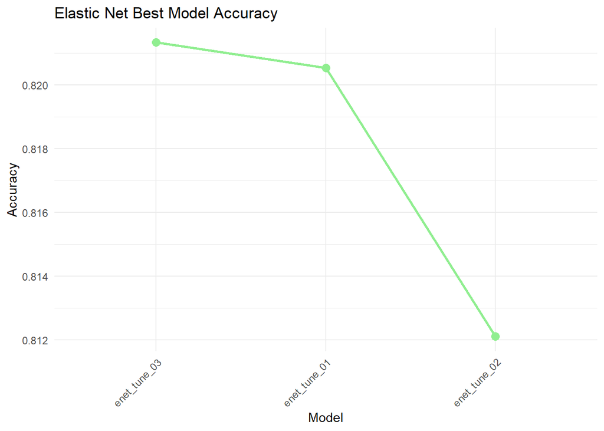

```r
ggplot(model_accuracies_enet, aes(x = reorder(Model, -Accuracy), y = Accuracy, group = 1)) +
  geom_line(color="lightgreen", size = 1) +
  geom_point(color="lightgreen",size = 3) +
  labs(x = "Model", y = "Accuracy", title = "Elastic Net Best Model Accuracy") +
  theme_minimal() +
  theme(axis.text.x = element_text(angle = 45, hjust = 1),
        legend.position = "bottom")
```

The model labeled `enet_tune_03` has an accuracy of 0.8213385 , which means it correctly predicts the outcome of the classification task about 82.13% of the time. This accuracy rate is the highest among all the models you’ve created, indicating that `enet_tune_03` is the most effective in predicting the outcome compared to the other models.

**Neural network**

1. Add categorical inputs to all main effect and all pairwise interactions of continuous inputs

```r
set.seed(1234)

nnet_default_01 <- train(outcome ~ Lightness + Saturation + (R + G + B + Hue + response)^2,
                       data = df_caret,
                       method = 'nnet',
                       metric = my_metric,
                       preProcess = c("center", "scale"),
                       trControl = my_ctrl,
                       trace = FALSE)

nnet_default_01
```

```
## Neural Network
##
## 835 samples
##   7 predictor
##   2 classes: 'event', 'non_event'
##
## Pre-processing: centered (27), scaled (27)
## Resampling: Cross-Validated (10 fold, repeated 3 times)
## Summary of sample sizes: 751, 751, 751, 752, 752, 752, ...
## Resampling results across tuning parameters:
##
##   size  decay  Accuracy   Kappa
##   1     0e+00  0.7847877  0.2793323
##   1     1e-04  0.7912849  0.3474661
##   1     1e-01  0.8140474  0.3965330
##   3     0e+00  0.8144061  0.4557135
##   3     1e-04  0.8139621  0.4508998
##   3     1e-01  0.8383547  0.5190654
##   5     0e+00  0.8279512  0.4891261
##   5     1e-04  0.8139568  0.4716161
##   5     1e-01  0.8379532  0.5239199
##
## Accuracy was used to select the optimal model using the largest value.
## The final values used for the model were size = 3 and decay = 0.1.
```

2. Polynomial transformations for the continuous variables R, G, and B, as their distributions.

```r
set.seed(1234)

nnet_default_02 <- train(outcome ~ poly(R, 2) + poly(G, 2) + poly(B, 2) + Hue + Lightness + Saturation,
                       data = df_caret,
                       method = 'nnet',
                       metric = my_metric,
                       preProcess = c("center", "scale"),
                       trControl = my_ctrl,
                       trace = FALSE)

nnet_default_02
```

```
## Neural Network
##
## 835 samples
##   6 predictor
##   2 classes: 'event', 'non_event'
##
## Pre-processing: centered (19), scaled (19)
## Resampling: Cross-Validated (10 fold, repeated 3 times)
## Summary of sample sizes: 751, 751, 751, 752, 752, 752, ...
## Resampling results across tuning parameters:
##
##   size  decay  Accuracy   Kappa
##   1     0e+00  0.8027547  0.3201291
##   1     1e-04  0.7996417  0.3428636
##   1     1e-01  0.8211808  0.4201530
##   3     0e+00  0.8075932  0.4165781
##   3     1e-04  0.8116233  0.4605987
##   3     1e-01  0.8315135  0.4952612
##   5     0e+00  0.8127664  0.4449987
##   5     1e-04  0.8100886  0.4477096
##   5     1e-01  0.8291987  0.4941655
##
## Accuracy was used to select the optimal model using the largest value.
## The final values used for the model were size = 3 and decay = 0.1.
```

3.All categorical and continuous variables

```r
set.seed(1234)

nnet_default_03 <- train(outcome ~ Lightness + Saturation + R + G + B + Hue + response,
                       data = df_caret,
                       method = 'nnet',
                       metric = my_metric,
                       preProcess = c("center", "scale"),
                       trControl = my_ctrl,
                       trace = FALSE)

nnet_default_03
```

```
## Neural Network
##
## 835 samples
##   7 predictor
##   2 classes: 'event', 'non_event'
##
## Pre-processing: centered (17), scaled (17)
## Resampling: Cross-Validated (10 fold, repeated 3 times)
## Summary of sample sizes: 751, 751, 751, 752, 752, 752, ...
## Resampling results across tuning parameters:
##
##   size  decay  Accuracy   Kappa
##   1     0e+00  0.8027926  0.2846186
##   1     1e-04  0.7952004  0.2474429
##   1     1e-01  0.8156107  0.3809241
##   3     0e+00  0.8016646  0.3777252
##   3     1e-04  0.7993111  0.4230511
##   3     1e-01  0.8366534  0.5041826
##   5     0e+00  0.7919783  0.3940996
##   5     1e-04  0.7976348  0.4079129
##   5     1e-01  0.8371835  0.5143087
##
## Accuracy was used to select the optimal model using the largest value.
## The final values used for the model were size = 5 and decay = 0.1.
```

```r
nnet_grid_01 <- expand.grid(size = c(5, 10, 20),
                         decay = exp(seq(-6, 2, length.out=11)))


nnet_grid_02 <- expand.grid(size = c(5, 10, 20),
                         decay = exp(seq(-6, 2, length.out=11)))


nnet_grid_03 <- expand.grid(size = c(5, 10, 20),
                         decay = exp(seq(-6, 2, length.out=11)))
```

```r
set.seed(1234)

nnet_tune_01 <- train( outcome ~ Lightness + Saturation + (R + G + B + Hue + response)^2,
                    data = df_caret,
                    method = 'nnet',
                    metric = my_metric,
                    tuneGrid = nnet_grid_01,
                    preProcess = c("center", "scale"),
                    trControl = my_ctrl,
                    trace = FALSE)
```

```r
set.seed(1234)

nnet_tune_02 <- train( outcome ~ poly(R, 2) + poly(G, 2) + poly(B, 2) + Hue + Lightness + Saturation,
                    data = df_caret,
                    method = 'nnet',
                    metric = my_metric,
                    tuneGrid = nnet_grid_02,
                    preProcess = c("center", "scale"),
                    trControl = my_ctrl,
                    trace = FALSE)
```

```r
set.seed(1234)

nnet_tune_03 <- train(outcome ~ Lightness + Saturation + R + G + B + Hue + response,
                    data = df_caret,
                    method = 'nnet',
                    metric = my_metric,
                    tuneGrid = nnet_grid_03,
                    preProcess = c("center", "scale"),
                    trControl = my_ctrl,
                    trace = FALSE)
```

**Best Performing Model - Accuracy**

```r
accuracy_model1nn <- mean(nnet_tune_01$results$Accuracy)
accuracy_model2nn <- mean(nnet_tune_02$results$Accuracy)
accuracy_model3nn <- mean(nnet_tune_03$results$Accuracy)



model_accuracies_nn <- tibble(
  Model = c("nnet_tune_01", "nnet_tune_02", "nnet_tune_03"),
  Accuracy = c(accuracy_model1nn, accuracy_model2nn, accuracy_model3nn)
)


model_accuracies_nn <- model_accuracies_nn %>%
  arrange(desc(Accuracy))

print(model_accuracies_nn)
```

```
## # A tibble: 3 × 2
##   Model        Accuracy
##   <chr>           <dbl>
## 1 nnet_tune_01    0.824
## 2 nnet_tune_02    0.822
## 3 nnet_tune_03    0.818
```

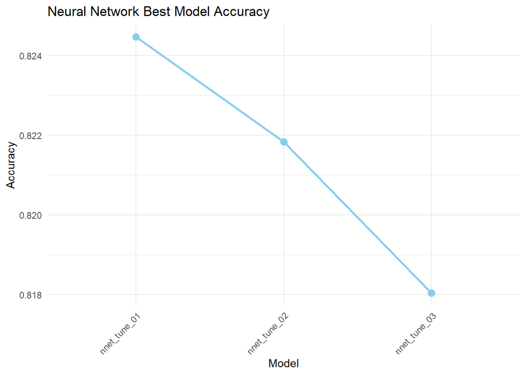

```r
ggplot(model_accuracies_nn, aes(x = reorder(Model, -Accuracy), y = Accuracy, group = 1)) +
  geom_line(color = "skyblue", size = 1) +
  geom_point(color = "skyblue", size = 3) +
  labs(x = "Model", y = "Accuracy", title = "Neural Network Best Model Accuracy") +
  theme_minimal() +
  theme(axis.text.x = element_text(angle = 45, hjust = 1),
        legend.position = "bottom")
```

The model labeled `nnet_tune_01` has an accuracy of 0.8244646 , which means it correctly predicts the outcome of the classification task about 82.44% of the time. This accuracy rate is the highest among all the models you’ve created, indicating that `nnet_tune_01` is the most effective in predicting the outcome compared to the other models.

**Random forest**

1. Add categorical inputs to all main effect and all pairwise interactions of continuous inputs

```r
set.seed(1234)


rf_default_01 <- train(outcome ~ Lightness + Saturation + (R + G + B + Hue + response)^2,
                     data = df_caret,
                     method = 'rf',
                     metric = my_metric,
                     trControl = my_ctrl,
                     importance = TRUE)

rf_default_01
```

```
## Random Forest
##
## 835 samples
##   7 predictor
##   2 classes: 'event', 'non_event'
##
## No pre-processing
## Resampling: Cross-Validated (10 fold, repeated 3 times)
## Summary of sample sizes: 751, 751, 751, 752, 752, 752, ...
## Resampling results across tuning parameters:
##
##   mtry  Accuracy   Kappa
##    2    0.8375088  0.4547122
##   14    0.8546967  0.5484036
##   27    0.8506997  0.5386409
##
## Accuracy was used to select the optimal model using the largest value.
## The final value used for the model was mtry = 14.
```

2. Polynomial transformations for the continuous variables R, G, and B, as their distributions.

```r
set.seed(1234)


rf_default_02 <- train( outcome ~ poly(R, 2) + poly(G, 2) + poly(B, 2) + Hue + Lightness + Saturation,
                     data = df_caret,
                     method = 'rf',
                     metric = my_metric,
                     trControl = my_ctrl,
                     importance = TRUE)

rf_default_02
```

```
## Random Forest
##
## 835 samples
##   6 predictor
##   2 classes: 'event', 'non_event'
##
## No pre-processing
## Resampling: Cross-Validated (10 fold, repeated 3 times)
## Summary of sample sizes: 751, 751, 751, 752, 752, 752, ...
## Resampling results across tuning parameters:
##
##   mtry  Accuracy   Kappa
##    2    0.8323922  0.4224076
##   10    0.8542520  0.5501011
##   19    0.8554281  0.5611358
##
## Accuracy was used to select the optimal model using the largest value.
## The final value used for the model was mtry = 19.
```

3. Interaction of the categorical inputs with all continuous inputs main effects

```r
set.seed(1234)


rf_default_03 <- train(outcome ~ Lightness * (R + G + B + Hue + response) + Saturation * (R + G + B + Hue + response),
                     data = df_caret,
                     method = 'rf',
                     metric = my_metric,
                     trControl = my_ctrl,
                     importance = TRUE)

rf_default_03
```

```
## Random Forest
##
## 835 samples
##   7 predictor
##   2 classes: 'event', 'non_event'
##
## No pre-processing
## Resampling: Cross-Validated (10 fold, repeated 3 times)
## Summary of sample sizes: 751, 751, 751, 752, 752, 752, ...
## Resampling results across tuning parameters:
##
##   mtry  Accuracy   Kappa
##    2    0.8228109  0.3726544
##   39    0.8483185  0.5406488
##   77    0.8443071  0.5317654
##
## Accuracy was used to select the optimal model using the largest value.
## The final value used for the model was mtry = 39.
```

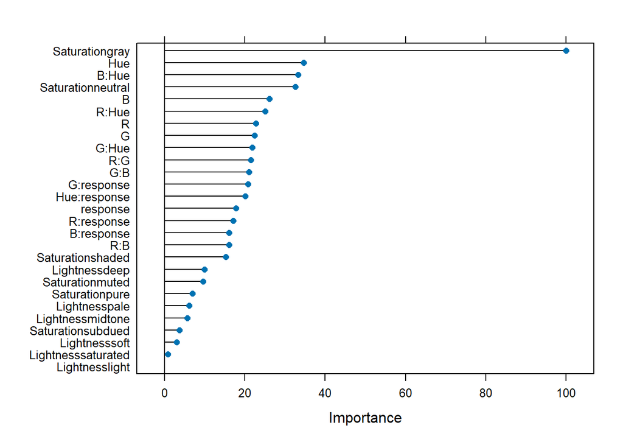

```r
plot( varImp(rf_default_01) )
```

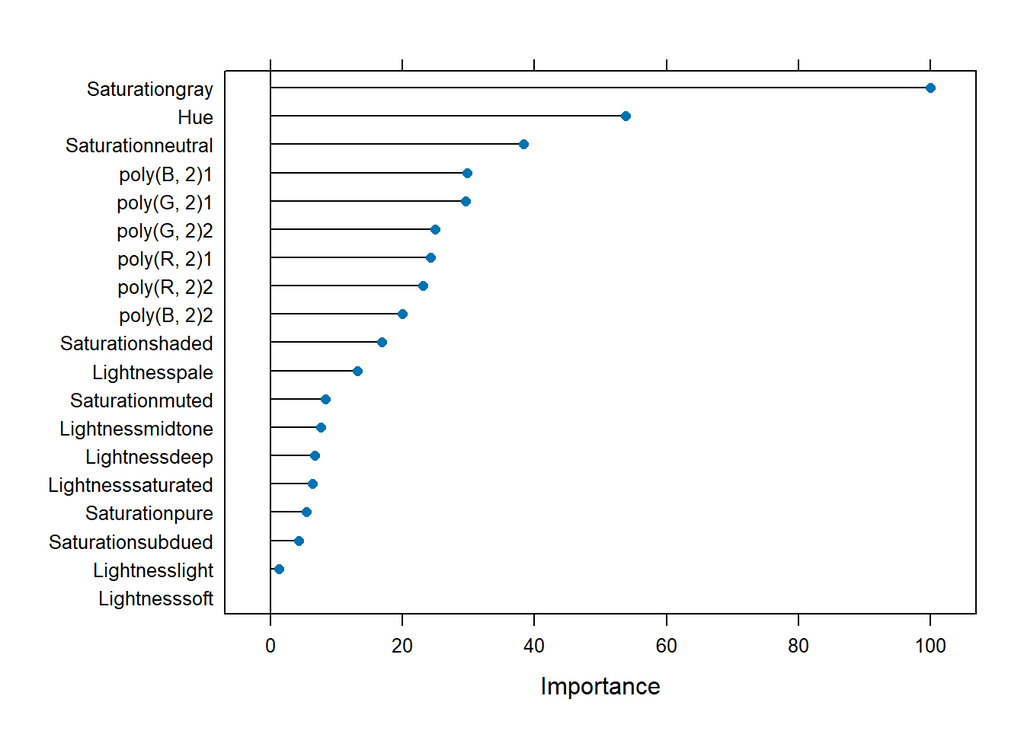

```r
plot( varImp(rf_default_02) )
```

[figure not shown]

```r
plot( varImp(rf_default_03) )
```

**Best Performing Model - Accuracy**

```r
accuracy_model1rf <- mean(rf_default_01$results$Accuracy)
accuracy_model2rf <- mean(rf_default_02$results$Accuracy)
accuracy_model3rf <- mean(rf_default_03$results$Accuracy)



model_accuracies_rf <- tibble(
  Model = c("rf_default_01", "rf_default_02", "rf_default_03"),
  Accuracy = c(accuracy_model1rf, accuracy_model2rf, accuracy_model3rf)
)


model_accuracies_rf <- model_accuracies_rf %>%
  arrange(desc(Accuracy))

print(model_accuracies_rf)
```

```
## # A tibble: 3 × 2
##   Model         Accuracy
##   <chr>            <dbl>
## 1 rf_default_01    0.848
## 2 rf_default_02    0.847
## 3 rf_default_03    0.838
```

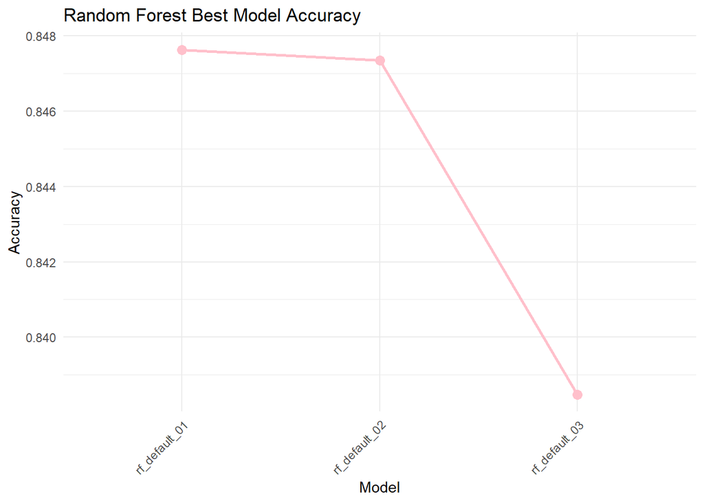

```r
ggplot(model_accuracies_rf, aes(x = reorder(Model, -Accuracy), y = Accuracy, group = 1)) +
  geom_line(color = "pink", size = 1) +
  geom_point(color = "pink", size = 3) +
  labs(x = "Model", y = "Accuracy", title = "Random Forest Best Model Accuracy") +
  theme_minimal() +
  theme(axis.text.x = element_text(angle = 45, hjust = 1),
        legend.position = "bottom")
```

The model labeled `rf_default_01` has an accuracy of 0.8476351 , which means it correctly predicts the outcome of the classification task about 84.76% of the time. This accuracy rate is the highest among all the models you’ve created, indicating that `rf_default_01` is the most effective in predicting the outcome compared to the other models.

**Gradient boosted tree**

1. Add categorical inputs to all main effect and all pairwise interactions of continuous inputs

```r
set.seed(1234)

gbt_default_01 <- train(outcome ~ (Lightness + Saturation + R + G + B + Hue + response)^2,
                     data = df_caret,
                     method = 'gbm',
                     metric = my_metric,
                     trControl = my_ctrl,
                     preProcess = c("center", "scale"),
                     verbose = FALSE)

gbt_default_01
```

```
## Stochastic Gradient Boosting
##
## 835 samples
##   7 predictor
##   2 classes: 'event', 'non_event'
##
## Pre-processing: centered (123), scaled (123)
## Resampling: Cross-Validated (10 fold, repeated 3 times)
## Summary of sample sizes: 751, 751, 751, 752, 752, 752, ...
## Resampling results across tuning parameters:
##
##   interaction.depth  n.trees  Accuracy   Kappa
##   1                   50      0.8204060  0.3642541
##   1                  100      0.8307240  0.4273635
##   1                  150      0.8402958  0.4660662
##   2                   50      0.8363228  0.4411768
##   2                  100      0.8471427  0.5025836
##   2                  150      0.8466932  0.5121893
##   3                   50      0.8435327  0.4823962
##   3                  100      0.8446710  0.5102361
##   3                  150      0.8522633  0.5415406
##
## Tuning parameter 'shrinkage' was held constant at a value of 0.1
##
## Tuning parameter 'n.minobsinnode' was held constant at a value of 10
## Accuracy was used to select the optimal model using the largest value.
## The final values used for the model were n.trees = 150, interaction.depth =
##  3, shrinkage = 0.1 and n.minobsinnode = 10.
```

2. Polynomial transformations for the continuous variables R, G, and B, as their distributions.

```r
set.seed(1234)


gbt_default_02 <- train( outcome ~ poly(R, 2) + poly(G, 2) + poly(B, 2) + Hue + Lightness + Saturation,
                     data = df_caret,
                     method = 'gbm',
                     metric = my_metric,
                     trControl = my_ctrl,
                     preProcess = c("center", "scale"),
                     verbose = FALSE)

gbt_default_02
```

```
## Stochastic Gradient Boosting
##
## 835 samples
##   6 predictor
##   2 classes: 'event', 'non_event'
##
## Pre-processing: centered (19), scaled (19)
## Resampling: Cross-Validated (10 fold, repeated 3 times)
## Summary of sample sizes: 751, 751, 751, 752, 752, 752, ...
## Resampling results across tuning parameters:
##
##   interaction.depth  n.trees  Accuracy   Kappa
##   1                   50      0.8236095  0.3819511
##   1                  100      0.8295859  0.4096551
##   1                  150      0.8327893  0.4243921
##   2                   50      0.8255796  0.3967133
##   2                  100      0.8383689  0.4638199
##   2                  150      0.8475440  0.5094529
##   3                   50      0.8383450  0.4558707
##   3                  100      0.8499251  0.5197681
##   3                  150      0.8543141  0.5428323
##
## Tuning parameter 'shrinkage' was held constant at a value of 0.1
##
## Tuning parameter 'n.minobsinnode' was held constant at a value of 10
## Accuracy was used to select the optimal model using the largest value.
## The final values used for the model were n.trees = 150, interaction.depth =
##  3, shrinkage = 0.1 and n.minobsinnode = 10.
```

3. Interaction of the categorical inputs with all continuous inputs main effects

```r
set.seed(1234)


gbt_default_03 <- train(outcome ~ Lightness * (R + G + B + Hue + response) + Saturation * (R + G + B + Hue + response),
                     data = df_caret,
                     method = 'gbm',
                     metric = my_metric,
                     trControl = my_ctrl,
                     preProcess = c("center", "scale"),
                     verbose = FALSE)

gbt_default_03
```

```
## Stochastic Gradient Boosting
##
## 835 samples
##   7 predictor
##   2 classes: 'event', 'non_event'
##
## Pre-processing: centered (77), scaled (77)
## Resampling: Cross-Validated (10 fold, repeated 3 times)
## Summary of sample sizes: 751, 751, 751, 752, 752, 752, ...
## Resampling results across tuning parameters:
##
##   interaction.depth  n.trees  Accuracy   Kappa
##   1                   50      0.8215916  0.3696857
##   1                  100      0.8295763  0.4273876
##   1                  150      0.8347306  0.4516556
##   2                   50      0.8355289  0.4384296
##   2                  100      0.8463438  0.4952372
##   2                  150      0.8511108  0.5222038
##   3                   50      0.8423416  0.4748128
##   3                  100      0.8514458  0.5279979
##   3                  150      0.8574461  0.5560027
##
## Tuning parameter 'shrinkage' was held constant at a value of 0.1
##
## Tuning parameter 'n.minobsinnode' was held constant at a value of 10
## Accuracy was used to select the optimal model using the largest value.
## The final values used for the model were n.trees = 150, interaction.depth =
##  3, shrinkage = 0.1 and n.minobsinnode = 10.
```

**Best Performing Model - Accuracy**

```r
accuracy_model1gbt <- mean(gbt_default_01$results$Accuracy)
accuracy_model2gbt <- mean(gbt_default_02$results$Accuracy)
accuracy_model3gbt <- mean(gbt_default_03$results$Accuracy)



model_accuracies_gbt <- tibble(
  Model = c("gbt_default_01", "gbt_default_02", "gbt_default_03"),
  Accuracy = c(accuracy_model1gbt, accuracy_model2gbt, accuracy_model3gbt)
)


model_accuracies_gbt <- model_accuracies_gbt %>%
  arrange(desc(Accuracy))

print(model_accuracies_gbt)
```

```
## # A tibble: 3 × 2
##   Model          Accuracy
##   <chr>             <dbl>
## 1 gbt_default_03    0.841
## 2 gbt_default_01    0.840
## 3 gbt_default_02    0.838
```

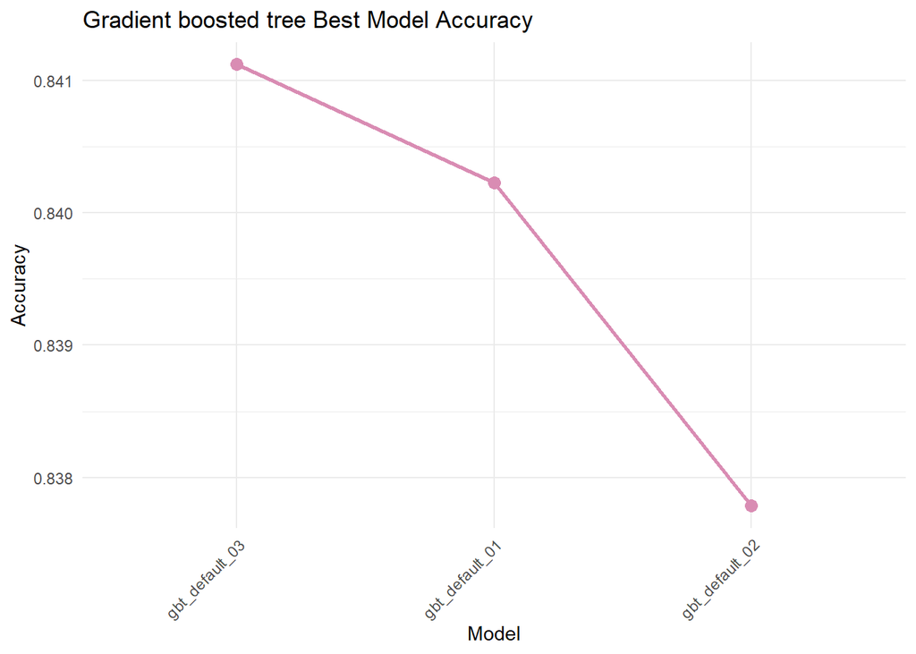

```r
ggplot(model_accuracies_gbt, aes(x = reorder(Model, -Accuracy), y = Accuracy, group = 1)) +
  geom_line(color = "#d98cb3", size = 1) +
  geom_point(color = "#d98cb3", size = 3) +
  labs(x = "Model", y = "Accuracy", title = "Gradient boosted tree Best Model Accuracy") +
  theme_minimal() +
  theme(axis.text.x = element_text(angle = 45, hjust = 1),
        legend.position = "bottom")
```

The model labeled `gbt_default_03` has an accuracy of 0.8411240 , which means it correctly predicts the outcome of the classification task about 84.11% of the time. This accuracy rate is the highest among all the models you’ve created, indicating that `gbt_default_03` is the most effective in predicting the outcome compared to the other models.

**Support Vector Machine (SVM)**

1. Add categorical inputs to all main effect and all pairwise interactions of continuous inputs

```r
library(kernlab)
set.seed(1234)

svm_default_01 <- train(outcome ~ (Lightness + Saturation + R + G + B + Hue + response)^2,
                     data = df_caret,
                     method = 'svmRadial',
                     metric = my_metric,
                     trControl = my_ctrl,
                     importance = TRUE)

svm_default_01
```

```
## Support Vector Machines with Radial Basis Function Kernel
##
## 835 samples
##   7 predictor
##   2 classes: 'event', 'non_event'
##
## No pre-processing
## Resampling: Cross-Validated (10 fold, repeated 3 times)
## Summary of sample sizes: 751, 751, 751, 752, 752, 752, ...
## Resampling results across tuning parameters:
##
##   C     Accuracy   Kappa
##   0.25  0.8156487  0.3354236
##   0.50  0.8188283  0.3539142
##   1.00  0.8196220  0.3590490
##
## Tuning parameter 'sigma' was held constant at a value of 0.005444959
## Accuracy was used to select the optimal model using the largest value.
## The final values used for the model were sigma = 0.005444959 and C = 1.
```

2. Polynomial transformations for the continuous variables R, G, and B, as their distributions.

```r
set.seed(1234)


svm_default_02 <- train( outcome ~ poly(R, 2) + poly(G, 2) + poly(B, 2) + Hue + Lightness + Saturation,
                     data = df_caret,
                     method = 'svmRadial',
                     metric = my_metric,
                     trControl = my_ctrl,
                     importance = TRUE)

svm_default_02
```

```
## Support Vector Machines with Radial Basis Function Kernel
##
## 835 samples
##   6 predictor
##   2 classes: 'event', 'non_event'
##
## No pre-processing
## Resampling: Cross-Validated (10 fold, repeated 3 times)
## Summary of sample sizes: 751, 751, 751, 752, 752, 752, ...
## Resampling results across tuning parameters:
##
##   C     Accuracy   Kappa
##   0.25  0.8224094  0.3689170
##   0.50  0.8228110  0.3705918
##   1.00  0.8187998  0.3626116
##
## Tuning parameter 'sigma' was held constant at a value of 0.03743592
## Accuracy was used to select the optimal model using the largest value.
## The final values used for the model were sigma = 0.03743592 and C = 0.5.
```

3. Interaction of the categorical inputs with all continuous inputs main effects

```r
set.seed(1234)


svm_default_03 <- train(outcome ~ Lightness * (R + G + B + Hue + response) + Saturation * (R + G + B + Hue + response),
                     data = df_caret,
                     method = 'svmRadial',
                     metric = my_metric,
                     trControl = my_ctrl,
                     importance = TRUE)

svm_default_03
```

```
## Support Vector Machines with Radial Basis Function Kernel
##
## 835 samples
##   7 predictor
##   2 classes: 'event', 'non_event'
##
## No pre-processing
## Resampling: Cross-Validated (10 fold, repeated 3 times)
## Summary of sample sizes: 751, 751, 751, 752, 752, 752, ...
## Resampling results across tuning parameters:
##
##   C     Accuracy   Kappa
##   0.25  0.8220078  0.3671644
##   0.50  0.8228110  0.3705918
##   1.00  0.8216205  0.3681132
##
## Tuning parameter 'sigma' was held constant at a value of 0.009133255
## Accuracy was used to select the optimal model using the largest value.
## The final values used for the model were sigma = 0.009133255 and C = 0.5.
```

**Best Performing Model - Accuracy**

```r
accuracy_model1svm <- mean(svm_default_01$results$Accuracy)
accuracy_model2svm <- mean(svm_default_02$results$Accuracy)
accuracy_model3svm <- mean(svm_default_03$results$Accuracy)



model_accuracies_svm <- tibble(
  Model = c("svm_default_01", "svm_default_02", "svm_default_03"),
  Accuracy = c(accuracy_model1svm, accuracy_model2svm, accuracy_model3svm)
)


model_accuracies_svm <- model_accuracies_svm %>%
  arrange(desc(Accuracy))

print(model_accuracies_svm)
```

```
## # A tibble: 3 × 2
##   Model          Accuracy
##   <chr>             <dbl>
## 1 svm_default_03    0.822
## 2 svm_default_02    0.821
## 3 svm_default_01    0.818
```

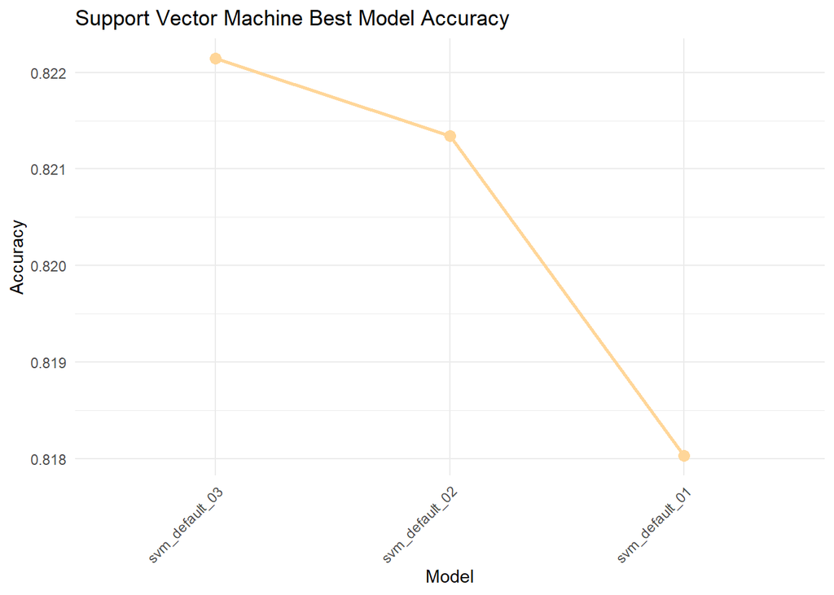

```r
ggplot(model_accuracies_svm, aes(x = reorder(Model, -Accuracy), y = Accuracy, group = 1)) +
  geom_line(color = "#ffd699", size = 1) +
  geom_point(color = "#ffd699", size = 3) +
  labs(x = "Model", y = "Accuracy", title = "Support Vector Machine Best Model Accuracy") +
  theme_minimal() +
  theme(axis.text.x = element_text(angle = 45, hjust = 1),
        legend.position = "bottom")
```

The model labeled `svm_default_03` has an accuracy of 0.8221465 , which means it correctly predicts the outcome of the classification task about 82.21% of the time. This accuracy rate is the highest among all the models you’ve created, indicating that `svm_default_03` is the most effective in predicting the outcome compared to the other models.

**k-Nearest Neighbors (k-NN)**

1. Add categorical inputs to all main effect and all pairwise interactions of continuous inputs

```r
set.seed(1234)

knn_default_01 <- train(outcome ~ (Lightness + Saturation + R + G + B + Hue + response)^2,
                     data = df_caret,
                     method = 'knn',
                     metric = my_metric,
                     trControl = my_ctrl,
                     preProcess = c("center", "scale"))

knn_default_01
```

```
## k-Nearest Neighbors
##
## 835 samples
##   7 predictor
##   2 classes: 'event', 'non_event'
##
## Pre-processing: centered (123), scaled (123)
## Resampling: Cross-Validated (10 fold, repeated 3 times)
## Summary of sample sizes: 751, 751, 751, 752, 752, 752, ...
## Resampling results across tuning parameters:
##
##   k  Accuracy   Kappa
##   5  0.8044330  0.3972466
##   7  0.8024436  0.3525919
##   9  0.8156062  0.3924234
##
## Accuracy was used to select the optimal model using the largest value.
## The final value used for the model was k = 9.
```

2. Polynomial transformations for the continuous variables R, G, and B, as their distributions.

```r
set.seed(1234)

knn_default_02 <- train( outcome ~ poly(R, 2) + poly(G, 2) + poly(B, 2) + Hue + Lightness + Saturation,
                     data = df_caret,
                     method = 'knn',
                     metric = my_metric,
                     trControl = my_ctrl,
                     preProcess = c("center", "scale"))

knn_default_02
```

```
## k-Nearest Neighbors
##
## 835 samples
##   6 predictor
##   2 classes: 'event', 'non_event'
##
## Pre-processing: centered (19), scaled (19)
## Resampling: Cross-Validated (10 fold, repeated 3 times)
## Summary of sample sizes: 751, 751, 751, 752, 752, 752, ...
## Resampling results across tuning parameters:
##
##   k  Accuracy   Kappa
##   5  0.8004215  0.3982711
##   7  0.8036340  0.3742954
##   9  0.8123793  0.4038314
##
## Accuracy was used to select the optimal model using the largest value.
## The final value used for the model was k = 9.
```

3. Interaction of the categorical inputs with all continuous inputs main effects

```r
set.seed(1234)

knn_default_03 <- train( outcome ~ Lightness * (R + G + B + Hue + response) + Saturation * (R + G + B + Hue + response),
                     data = df_caret,
                     method = 'knn',
                     metric = my_metric,
                     trControl = my_ctrl,
                     preProcess = c("center", "scale"))

knn_default_03
```

```
## k-Nearest Neighbors
##
## 835 samples
##   7 predictor
##   2 classes: 'event', 'non_event'
##
## Pre-processing: centered (77), scaled (77)
## Resampling: Cross-Validated (10 fold, repeated 3 times)
## Summary of sample sizes: 751, 751, 751, 752, 752, 752, ...
## Resampling results across tuning parameters:
##
##   k  Accuracy   Kappa
##   5  0.8032425  0.3920052
##   7  0.8044469  0.3572866
##   9  0.8164049  0.3887991
##
## Accuracy was used to select the optimal model using the largest value.
## The final value used for the model was k = 9.
```

**Best Performing Model - Accuracy**

```r
accuracy_model1knn <- mean(knn_default_01$results$Accuracy)
accuracy_model2knn <- mean(knn_default_02$results$Accuracy)
accuracy_model3knn <- mean(knn_default_03$results$Accuracy)



model_accuracies_knn <- tibble(
  Model = c("knn_default_01", "knn_default_02", "knn_default_03"),
  Accuracy = c(accuracy_model1knn, accuracy_model2knn, accuracy_model3knn)
)


model_accuracies_knn <- model_accuracies_knn %>%
  arrange(desc(Accuracy))

print(model_accuracies_knn)
```

```
## # A tibble: 3 × 2
##   Model          Accuracy
##   <chr>             <dbl>
## 1 knn_default_03    0.808
## 2 knn_default_01    0.807
## 3 knn_default_02    0.805
```

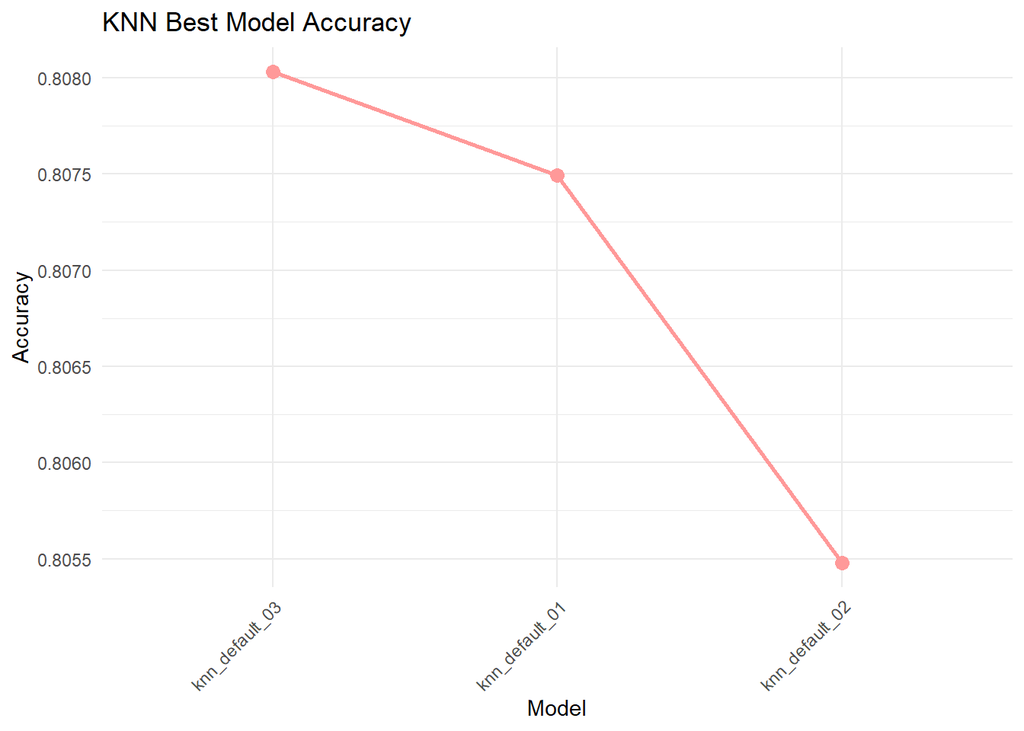

```r
ggplot(model_accuracies_knn, aes(x = reorder(Model, -Accuracy), y = Accuracy, group = 1)) +
  geom_line(color = "#ff9999", size = 1) +
  geom_point(color = "#ff9999", size = 3) +
  labs(x = "Model", y = "Accuracy", title = "KNN Best Model Accuracy") +
  theme_minimal() +
  theme(axis.text.x = element_text(angle = 45, hjust = 1),
        legend.position = "bottom")
```

The model labeled `knn_default_03` has an accuracy of 0.8080314 , which means it correctly predicts the outcome of the classification task about 80.80% of the time. This accuracy rate is the highest among all the models you’ve created, indicating that `knn_default_03` is the most effective in predicting the outcome compared to the other models.